# Ideology as the Driver of Political Opinion

GSS 2022 Descriptive Report

Author

Eduardo M.

# 1 Summary

This descriptive analysis of the 2022 General Social Survey (GSS) reveals that **ideological orientation—self-placement** as liberal, moderate, or conservative—emerges as **the most consistent and powerful predictor of public attitudes** in the United States. More than any demographic trait or even partisan identification, ideology shapes beliefs about public policy, institutional trust, and moral issues.

Compared to age, sex, income, or party affiliation, ideological identity offers sharper divisions and clearer insights into how Americans view social and political life. As we move through the results, a recurring pattern emerges: ideology consistently sorts opinion, while **sociodemographic factors often play a secondary role** or influence opinion indirectly through ideological orientation.

# 2 Ideological Identity and Political affiliation

**Public opinion in the U.S. continues to be structured more by ideological orientation than by traditional partisan affiliation or demographic traits.** While party identification remains a key political marker, it increasingly reflects underlying ideological leanings rather than serving as an independent force. This section explores how respondents place themselves on the ideological spectrum, how they identify with political parties, and how these patterns intersect with age and gender.

### 2.0.2 Descriptive summary of findings

Most respondents place themselves near the ideological center. As shown in the charts below, moderates and conservatives form the largest ideological groups, followed by liberals. However, despite this central tendency in self-placement, the distribution of political identification reveals a different story.

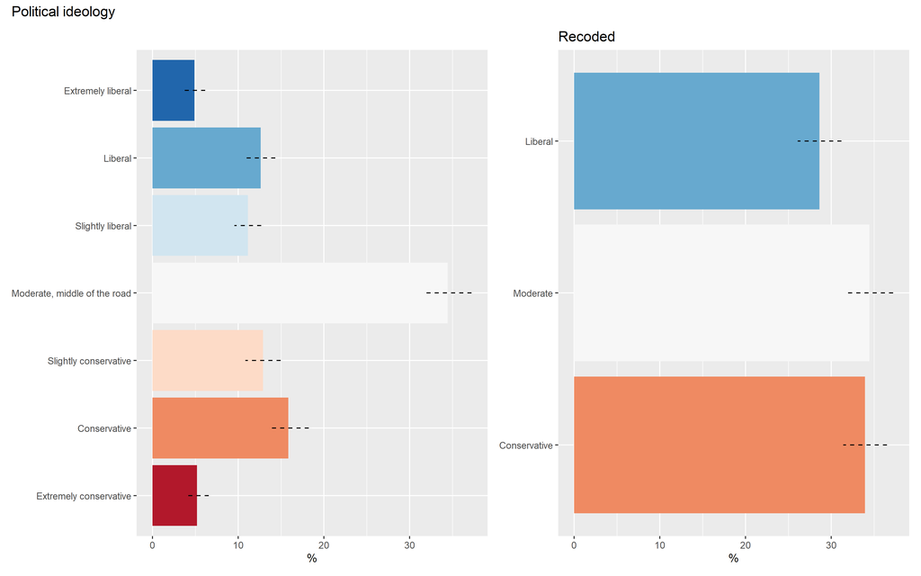

Interestingly, despite the fact that more respondents identify as conservatives than liberals, there are more Democrats than Republicans in the sample. This uncoupling of party and ideology is a central dynamic in contemporary American politics.

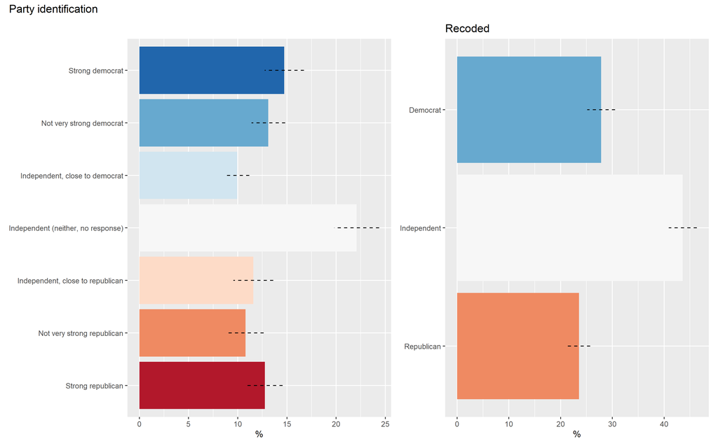

A closer look at ideological self-placement versus partisanship reveals an important distinction: while many people identify as neutral ideologically, their party affiliation tends to be more polarized. That is, people report centrist ideological positions but still align themselves with one of the two major parties or with strong leanings toward them.

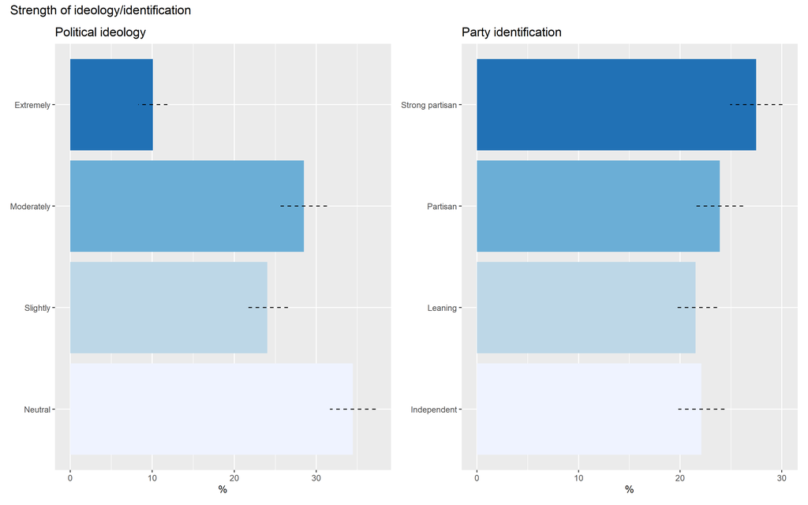

### 2.0.3 Role of Ideology and Sociodemographics

Gender differences are consistent with prior research: women are more likely to identify as liberal and Democratic, while men are more likely to identify as conservative. However, the gender gap in party ID is less pronounced: men are not significantly more Republican than women, suggesting that gendered ideological leanings may not always translate into party alignment.

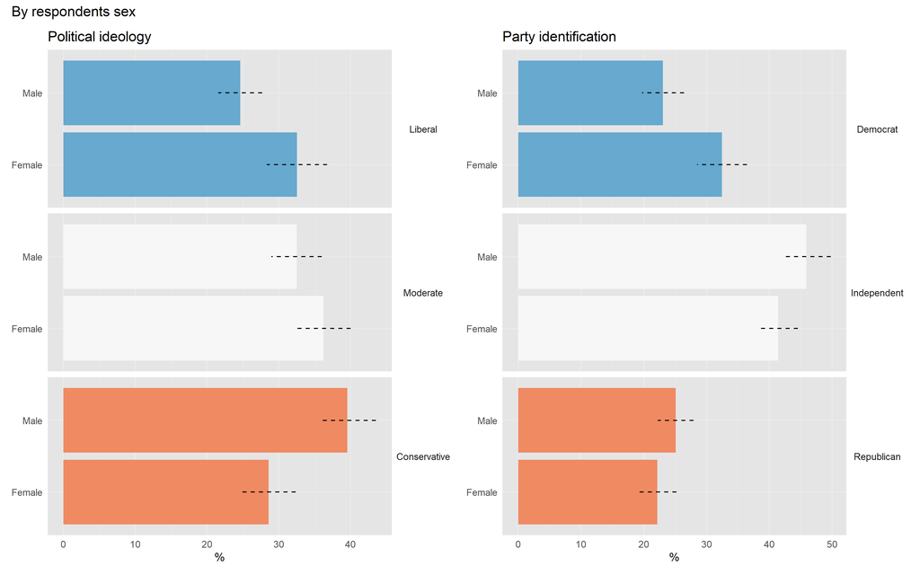

When it comes to age, younger respondents are more likely to identify as political independents, reflecting broader generational detachment from parties. However, this does not necessarily reflect ideological moderation: many young people identify as liberal, despite avoiding partisan labels.

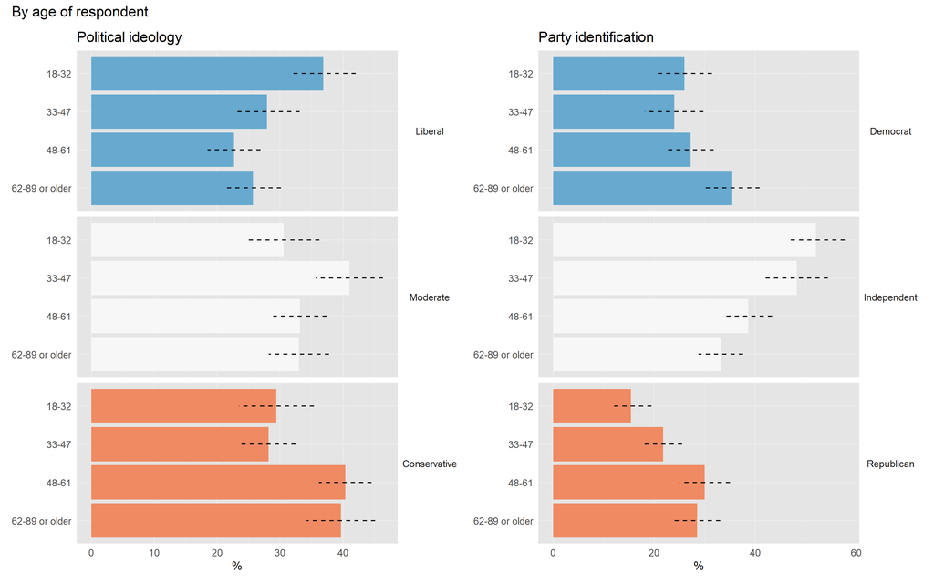

# 3 Policy Preferences: Death Penalty, Gun Permits, Marijuana

**Policy views on criminal justice and regulation reflect pronounced ideological divides.** Respondents were asked about their support for the death penalty, gun permit laws, and the legalization of marijuana.

### 3.0.1 Summary of Key Points

- Support for punitive policies (death penalty, gun rights) is high, especially among conservatives.
- Liberals show greater support for marijuana legalization and opposition to harsh punishments.
- Nonresponse on marijuana suggests measurement sensitivity or political disengagement.
- Political ideology provides a clearer explanation of attitudes than demographic background.

### 3.0.2 Descriptive summary of findings

Support for the death penalty is high (∼58%), followed by support for requiring gun permits (∼45%). Marijuana legalization has lower support (26%), and an unusually high nonresponse rate: over 60% of respondents either chose “Don’t know” or did not answer.

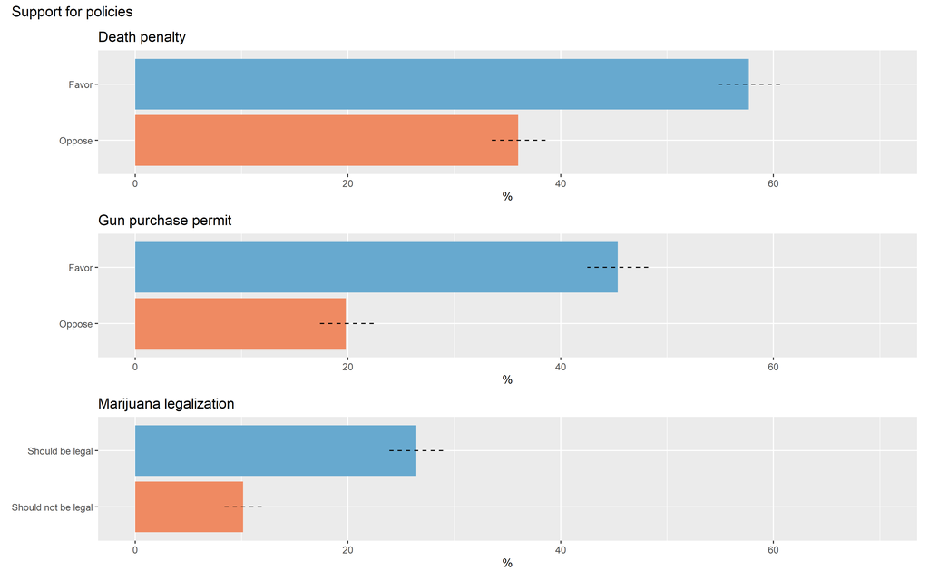

### 3.0.3 Role of Ideology and Sociodemographics

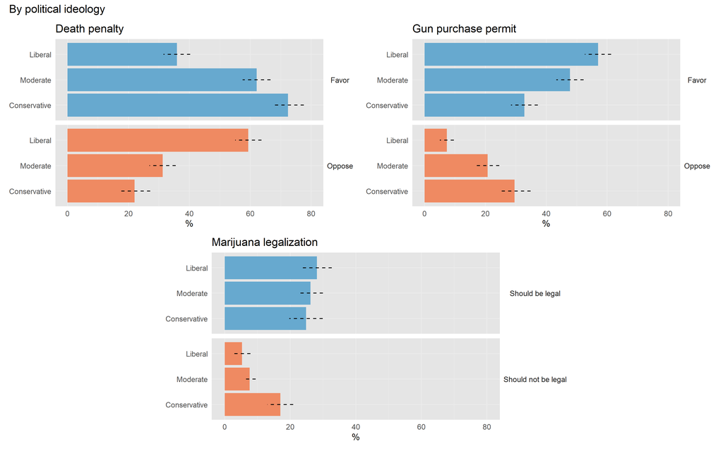

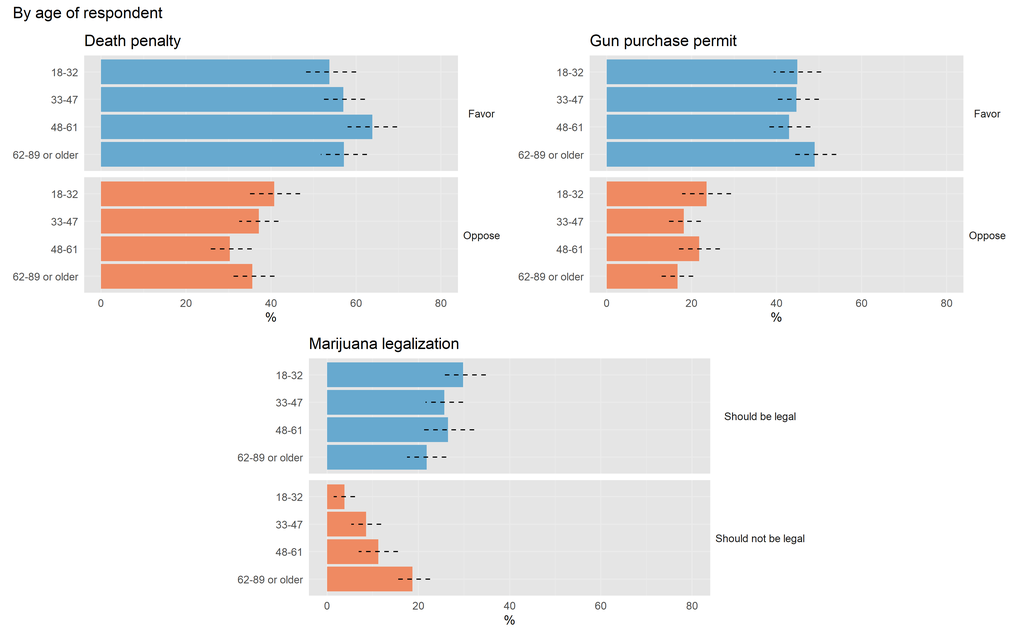

# 4 Abortion: General Beliefs and Specific Scenarios

**Abortion remains one of the most morally charged issues in American public life.** This section examines both general abortion attitudes (pro-choice vs. pro-life) and opinions across specific circumstances (e.g., health risk, rape, gender selection).

### 4.0.2 Descriptive summary of findings

More respondents identify as pro-choice than pro-life, and strong positions (“strongly pro-choice” or “strongly pro-life”) are more common than weakly held ones. When asked about specific abortion scenarios, a clear hierarchy of support emerges:

- Highest support is for abortions in cases of rape or when the woman’s health is at risk.
- The lowest levels of support are for abortions based on gender selection.
- The rest of the scenarios have a mid level of support.

Nonresponse rates are high across all scenarios (60%+), possibly reflecting discomfort or sensitivity around the topic.

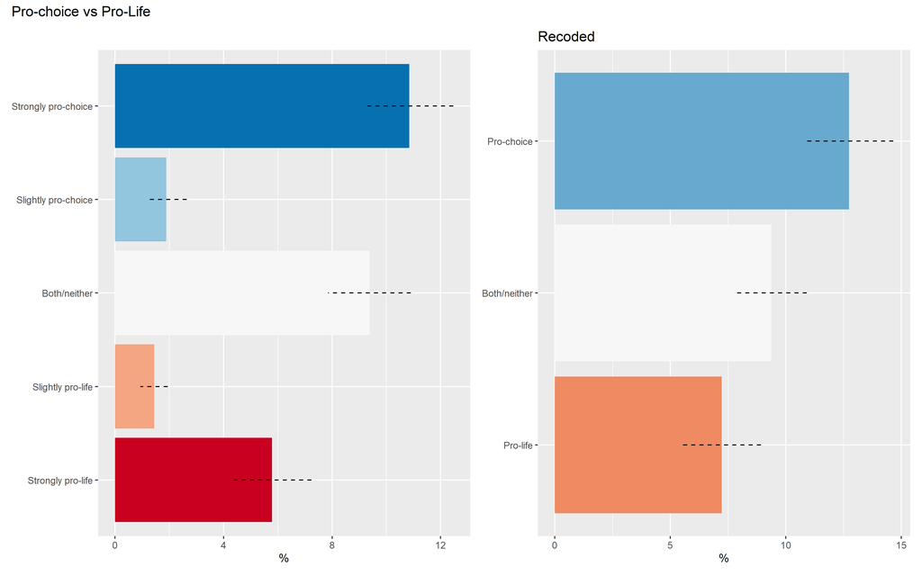

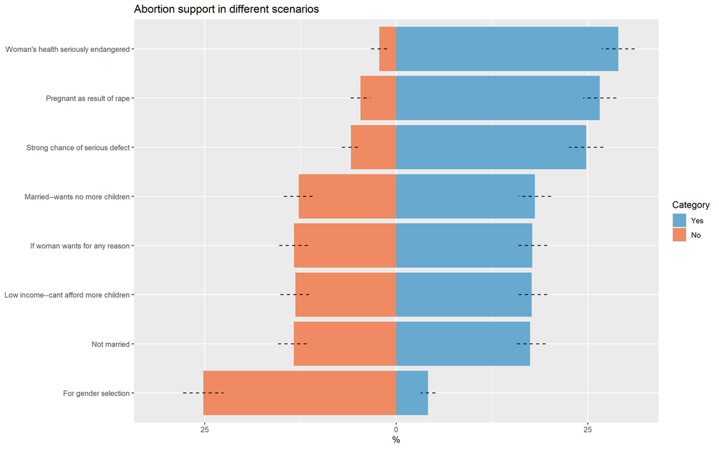

### 4.0.3 Role of Ideology and Sociodemographics

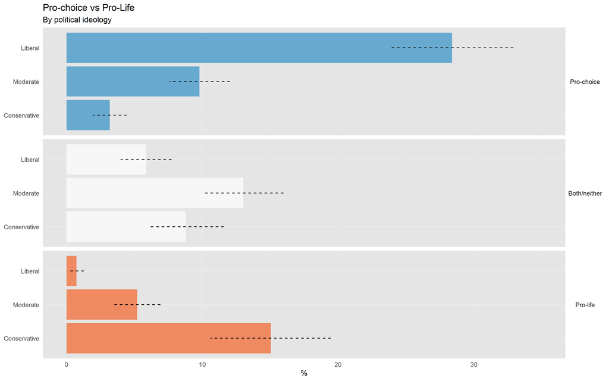

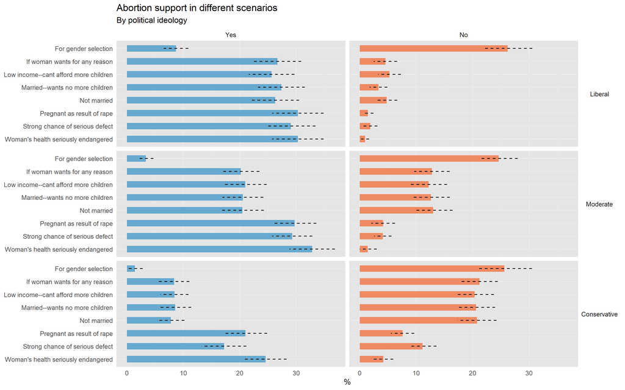

Gender differences appear only in specific scenarios. For example, men are slightly less opposed to abortion in cases of rape.

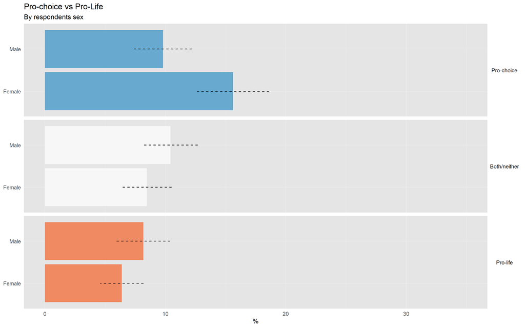

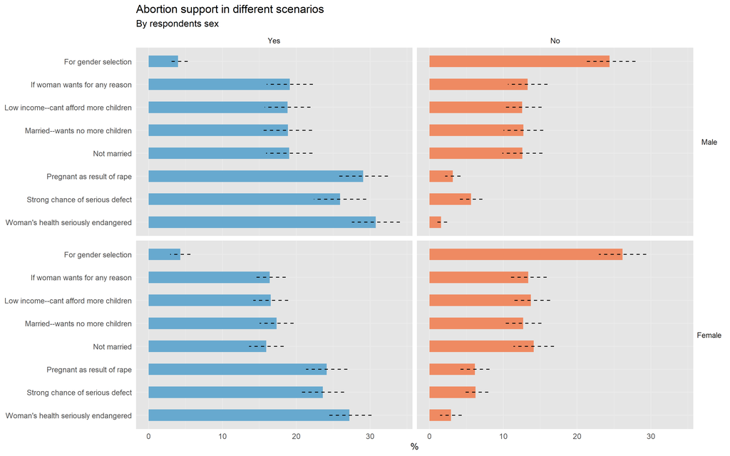

# 5 Institutional Trust

This section explores public **confidence in a variety of institutions**, from the military and science to Congress and the media.

### 5.0.1 Summary of Key Points

- Trust is high for professional and scientific institutions, low for political ones.
- Ideology polarizes attitudes: liberals and conservatives trust entirely different sectors.
- Sociodemographic influences are minimal compared to ideological effects.

### 5.0.2 Descriptive summary of findings

Overall, the military, scientific community, and medicine are the most trusted institutions. In contrast, Congress, the press, television and the executive branch receive the lowest levels of confidence. These patterns reveal general skepticism toward government but greater trust in professional or technical institutions.

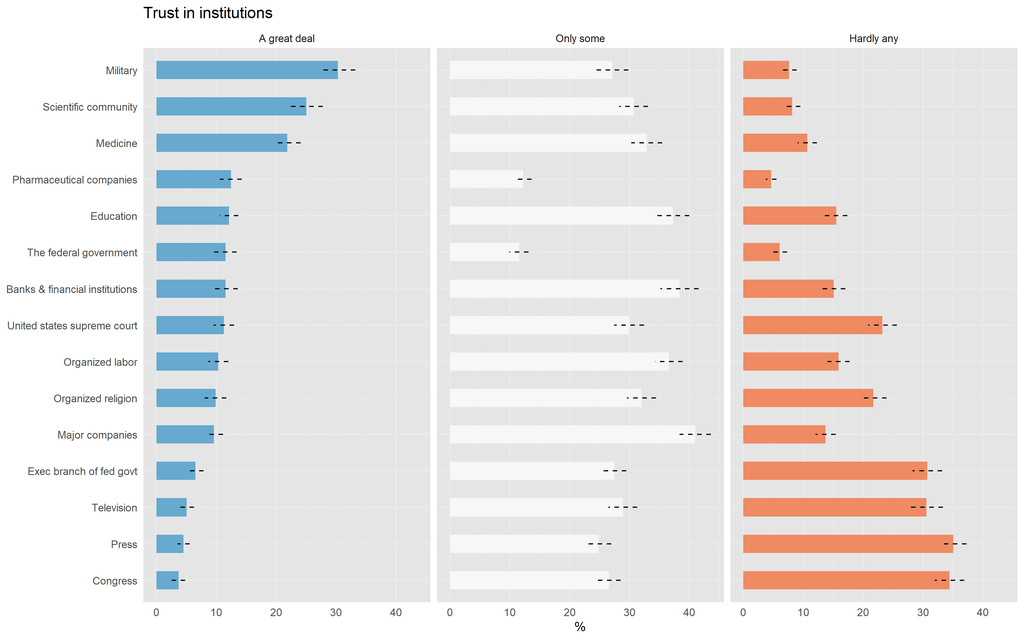

### 5.0.3 Role of Ideology and Sociodemographics

Institutional trust is heavily shaped by political ideology:

- Liberals tend to trust more the pharmaceutical companies, the scientific community, the press, and education.
- Conservatives express higher trust in the military and organized religion.
- Government institutions divide trust: liberals are more supportive of the executive branch, while conservatives trust the judiciary more.

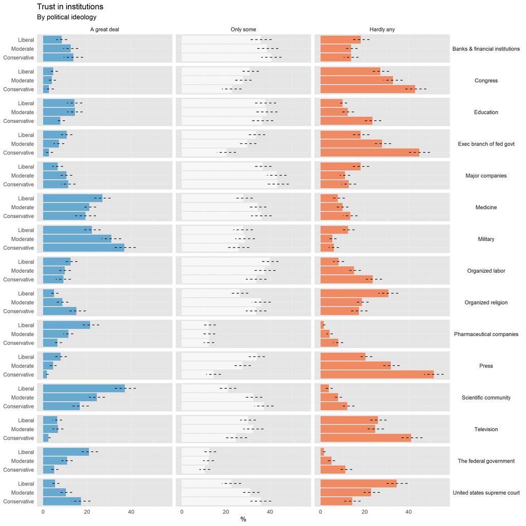

Demographic differences (age, sex, education) exist but are modest in comparison. Ideology clearly dominates the trust landscape.

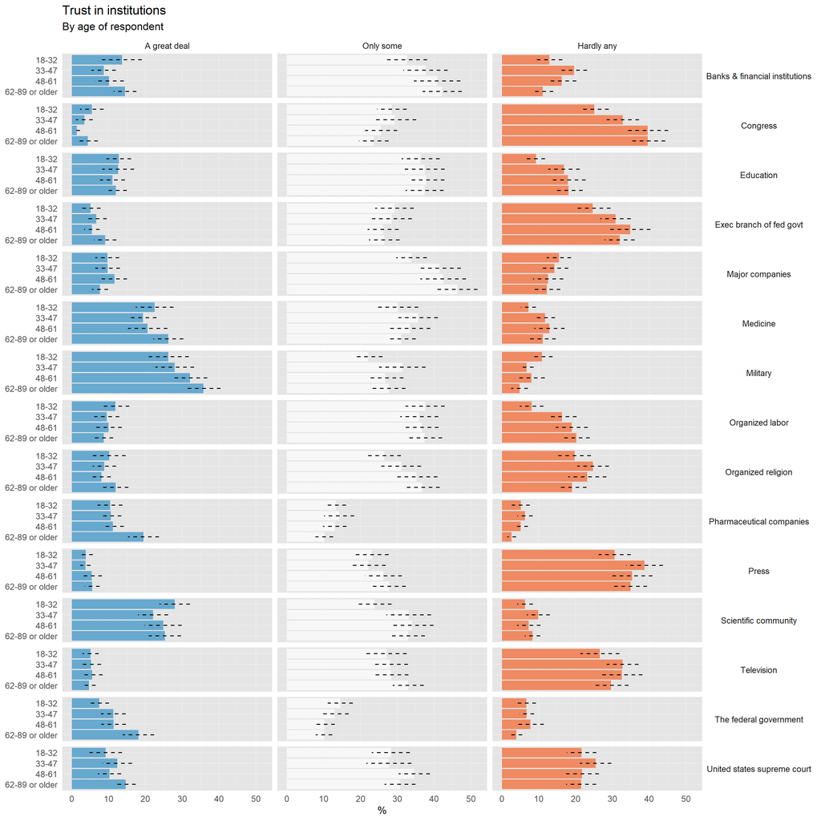

# 6 Final Conclusions

The findings from the 2022 GSS paint a consistent and compelling picture: **ideological identity is the most powerful predictor of public opinion across a wide range of domains.** Whether evaluating support for public policy, trust in institutions, or views on abortion, the distinction between liberal, moderate, and conservative orientations offers sharper explanatory power than demographic variables like age, gender, or even party identification.

In sum, **understanding Americans’ beliefs today requires understanding their ideological identities first and foremost.** As the country navigates complex debates around policy, rights, and governance, ideology remains the clearest lens through which these opinions take shape.

# 7 Methodology Summary

| **Field** | **Description** |
| --- | --- |
| **Survey Name** | General Social Survey (GSS) – 2022 Cross-Section |
| **Organization** | NORC at the University of Chicago |
| **Sample Design** | Multi-stage, clustered, stratified, area probability sample with unequal probabilities of selection |
| **Mode of Data Collection** | Mixed-mode: web-first and face-to-face-first, with phone and mail follow-up |
| **Fieldwork Period** | May to December 2022 |
| **Sample Size** | 3,544 completed interviews |
| **Weight Adjustments** | Includes corrections for non-response, within-household selection, and post-stratification on key demographics |
| **Analysis Method** | Design-based estimation using R’s `survey` package with: `ids = vpsu`, `strata = vstrat`, `weights = wtssnrps` |